# Differential expression

## Introduction

Outline:

```r
# packages:
library(pheatmap)
library(Matrix)
# load data:
mydir <- "//nanostring.local/RND/analysis-files/pdanaher/vignette/"
norm <- readRDS(paste0(mydir, "/processed_data/norm.RDS"))
metadata <- readRDS(paste0(mydir, "/processed_data/metadata_with_spatialcontext.RDS"))
celltype <- readRDS(paste0(mydir, "/processed_data/celltype.RDS"))
xy <- readRDS(paste0(mydir, "/processed_data/xy.RDS"))
```

## Filtering for analyzeable genes

Because cell segmentation is imperfect, genes that have low expression in your cell type of interest - but that have high expression in its neighboring cells - have unreliable expression profiles and often emerge as strong false positives in DE analyses. See [here](https://github.com/Nanostring-Biostats/CosMx-Analysis-Scratch-Space/blob/Main/blog/segmentation%20errors%20and%20DE.md) for more.

```r
# NEED TO IMPLEMENT AN ACTUAL FILTER HERE
analyzable <- matrix(TRUE, nrow = ncol(norm), ncol = length(unique(celltype)),
                     dimnames = list(colnames(norm), unique(celltype)))
```

## Defining a DE question

Differential expression models let us ask, “how does a cell type respond to its environment?” A great many biological questions can be framed this way.

For our example, we’ll consider the question, “how do mesangial cells change gene expression in response to nearby macrophages?”

Formalizing this, we might write the model: *E(y) = f(number of nearby macrophages)*. This says that expected expression of a gene in our cell type (*y*) is some function of the number of nearby macrophages.

We have a simple enough question, and a correspondingly simple model. But we should remember that mesangial cells are probably responding to many factors in their environment, not just macrophages. If we omit any of these factors from our DE model, it will be incomplete, with the omitted variable acting as a unmodeled confounder, biasing our results. Biology is complex, and we’ll never manage to specify a complete model for the local factors acting on podocyte gene expression, but we should try our best to capture the major factors.

So instead, we might try the following model:

This model accounts for other immune impacts on podocyte expression and for any impact of glomerulus composition on mesangial cells. (Mesangial cells live alongside podocytes and glomerular endothelial cells in glomeruli.) It also adjust for spatial cluster, which is reasonable to do whenever your variable of interest is largely uncorrelated with spatial cluster. In this example, if one of the spatial clusters was driven by local macrophage density, it would confuse interpretation of our results.

Finally, we have the disadvantage of not many tissues in our study, but the benefit of many cells per tissue. In this setting, it becomes useful to run our model separately for each tissue. Then we can see whether any genes are consistently DE across tissues. This cross-tissue comparison gives us confidence that our findings aren’t idiosyncratic to any single tissue. It also reveals interesting between-tissue heterogeneity.

## Very fast exploratory DE

The most accurate DE models can take a long time to run. If you want to quickly explore a DE question, with imperfect accuracy, you can use the below code, which uses matrix algebra to simultaneously run a linear model for every gene in your data.

To be clear: if you really want to hang your hat on a p-value, we recommend a more principled model than the simple linear models implemented below.

```r
# subset on only mesangial cells:
inds <- celltype == "Mesangial.cell"

# subset on only the analyzable genes \
# (those expressed above contamination as calculated above)
usegenes <- names(which(analyzable[, "Mesangial.cell"]))
length(usegenes)
```

```
#> [1] 960
```

```r
# get the design matrix to be used in every gene's model:
templm = lm(norm[inds, 1] ~ metadata$n_mac_neighbors[inds] + metadata$n_glom_endo_neighbors[inds] + metadata$n_lymphoid_neighbors[inds] + as.factor(metadata$spatialclust[inds]))
X = model.matrix(templm)
# clean up column names in the design matrix:
colnames(X)
```

```
#> [1] "(Intercept)"
#> [2] "metadata$n_mac_neighbors[inds]"
#> [3] "metadata$n_glom_endo_neighbors[inds]"
#> [4] "metadata$n_lymphoid_neighbors[inds]"
#> [5] "as.factor(metadata$spatialclust[inds])2"
#> [6] "as.factor(metadata$spatialclust[inds])3"
#> [7] "as.factor(metadata$spatialclust[inds])4"
#> [8] "as.factor(metadata$spatialclust[inds])5"
#> [9] "as.factor(metadata$spatialclust[inds])6"
```

```r
colnames(X) <- gsub("metadata\\$", "", colnames(X))
colnames(X) <- gsub("\\[inds\\]", "", colnames(X))
colnames(X) <- gsub("\\)", "", colnames(X))
colnames(X) <- gsub("\\(", "", colnames(X))
colnames(X) <- gsub("as.factor", "", colnames(X))
colnames(X)
```

```
#> [1] "Intercept"             "n_mac_neighbors"       "n_glom_endo_neighbors"
#> [4] "n_lymphoid_neighbors"  "spatialclust2"         "spatialclust3"
#> [7] "spatialclust4"         "spatialclust5"         "spatialclust6"
```

```r
head(X)
```

```
#>           Intercept n_mac_neighbors n_glom_endo_neighbors n_lymphoid_neighbors
#> c_1_1_168         1               0                     1                    7
#> c_1_1_206         1               0                     1                   10
#> c_1_1_252         1               0                     1                   10
#> c_1_1_276         1               0                     2                   12
#> c_1_1_279         1               0                     2                    6
#> c_1_1_294         1               0                     0                    8
#>           spatialclust2 spatialclust3 spatialclust4 spatialclust5 spatialclust6
#> c_1_1_168             0             1             0             0             0
#> c_1_1_206             0             1             0             0             0
#> c_1_1_252             0             1             0             0             0
#> c_1_1_276             0             1             0             0             0
#> c_1_1_279             0             1             0             0             0
#> c_1_1_294             0             1             0             0             0
```

```r
# now use matrix algebra to run a lm for every gene at once:
# get the estimates:
beta <- as.matrix(solve(t(X) %*% X) %*% t(X) %*% norm[inds, usegenes])
beta[, 1:5]
```

```
#>                               AATK         ABL1         ABL2           ACE
#> Intercept              0.046467555  0.082556864  0.028289694  0.0264745720
#> n_mac_neighbors       -0.001149510  0.012527295 -0.020156070 -0.0120868112
#> n_glom_endo_neighbors  0.002560000 -0.002419704  0.001042239 -0.0011712643
#> n_lymphoid_neighbors   0.002648242  0.001036966 -0.001755006 -0.0006710414
#> spatialclust2          0.015239423 -0.018267459  0.023369537 -0.0024105408
#> spatialclust3         -0.006512988 -0.024975792  0.047640529  0.0227459187
#> spatialclust4         -0.020741565  0.005249961  0.032652920  0.0143241039
#> spatialclust5         -0.050587042  0.482098973 -0.025559685 -0.0254307298
#> spatialclust6         -0.040391556 -0.082540172 -0.022284688  0.0406597469
#>                                ACE2
#> Intercept              0.0380067335
#> n_mac_neighbors       -0.0052042924
#> n_glom_endo_neighbors  0.0010607701
#> n_lymphoid_neighbors   0.0002849827
#> spatialclust2          0.0018367101
#> spatialclust3          0.0141326493
#> spatialclust4          0.0011193529
#> spatialclust5         -0.0384500400
#> spatialclust6          0.0778740871
```

```r
# get the SEs:
resids <- norm[inds, usegenes] - X %*% beta
rss <- colSums(resids^2)
sigmasquared <- rss / (nrow(X) - ncol(X))
ses <- sqrt(t(t(diag(solve(t(X) %*% X)))) %*% sigmasquared)
# and the p-value:
ps <- 2 * (1 - pt(abs(beta) / ses, df = nrow(X) - ncol(X)))

if (FALSE) {   # THIS NEEDS REVISION
  # convert from linear change in expression to a log2(fold-change):
  binaryvariables = paste0("spatialclust", 2:6)
  continuousvariables = c("n_mac_neighbors", "n_glom_endo_neighbors", "n_lymphoid_neighbors")
  log2fc = beta * NA
  # for binary variables, record the fold-change associated with the variable:
  for (name in binaryvariables) {
    log2fc[name, ] <- log2((beta[name, ] + beta["Intercept", ]) / beta["Intercept", ])
  }
  # for continuous variables, record the fold-change associated with a 1 SD increase in the variable:
  for (name in binaryvariables) {
    log2fc[name, ] <- log2((beta[name, ] * sd(X[, name]) +  beta["Intercept", ]) / beta["Intercept", ])
  }
}

## confirm it reproduces lm():
# basic lm results:
summary(templm)$coef[, c("Estimate", "Std. Error", "Pr(>|t|)")]
```

```
#>                                             Estimate  Std. Error  Pr(>|t|)
#> (Intercept)                              0.046467555 0.044699534 0.2986382
#> metadata$n_mac_neighbors[inds]          -0.001149510 0.014257423 0.9357457
#> metadata$n_glom_endo_neighbors[inds]     0.002560000 0.002293914 0.2645205
#> metadata$n_lymphoid_neighbors[inds]      0.002648242 0.002625544 0.3132330
#> as.factor(metadata$spatialclust[inds])2  0.015239423 0.047256168 0.7471094
#> as.factor(metadata$spatialclust[inds])3 -0.006512988 0.047845570 0.8917322
#> as.factor(metadata$spatialclust[inds])4 -0.020741565 0.049010012 0.6721744
#> as.factor(metadata$spatialclust[inds])5 -0.050587042 0.125811878 0.6876527
#> as.factor(metadata$spatialclust[inds])6 -0.040391556 0.070976833 0.5693475
```

```r
# our matrix algebra results:
cbind(beta[, 1], ses[, 1], ps[, 1])
```

```
#>                               [,1]        [,2]      [,3]
#> Intercept              0.046467555 0.044699534 0.2986382
#> n_mac_neighbors       -0.001149510 0.014257423 0.9357457
#> n_glom_endo_neighbors  0.002560000 0.002293914 0.2645205
#> n_lymphoid_neighbors   0.002648242 0.002625544 0.3132330
#> spatialclust2          0.015239423 0.047256168 0.7471094
#> spatialclust3         -0.006512988 0.047845570 0.8917322
#> spatialclust4         -0.020741565 0.049010012 0.6721744
#> spatialclust5         -0.050587042 0.125811878 0.6876527
#> spatialclust6         -0.040391556 0.070976833 0.5693475
```

## Plotting and exploring DE results

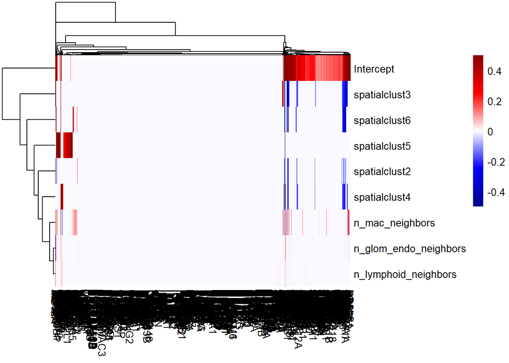

```r
## a nice way to look at results across several variables and all genes:
## heatmap of only the significant effect sizes:
pheatmap(beta * (ps < 1e-2), col = colorRampPalette(c("darkblue", "blue", "white", "red", "darkred"))(100),
         breaks = seq(-0.5, 0.5, length.out = 101))
```

## Notes on interpretation

Thanks to the huge number of cells in most experiments, DE analysis in CosMx data often returns spectacularly significant p-values. Sadly, these should not be taken as irrefutably convincing evidence. High sample size (number of cells) gives high power to detect changes in biology, but also high power to detect biases induced by technical artifacts and by biological variables omitted from DE models. In other words, if your model omits any confounder (as all models inevitably do), a DE analysis on tens of thousands of cells will easily find genes impacted by this confounder to be “significant”.

The countermeasure to this unfortunate statistical power is to evaluate genes based on their effect size, not on their p-values alone. While a minor confounder leads to smaller and smaller p-values as N increases, the bias it induces in a gene’s effect size will remain small.

In short, act as if you model accounts for major influences on gene expression but omits many minor influances, and only get excited about large effect sizes. A good rule of thumb is that a change in expression of +/-20% is believable; for effect sizes smaller than this some skepticism is advised.